# Topic modeling

Pablo Barbera

March 30, 2016

## Topic Modeling

While supervised learning is used when we know the categories we want to produce, unsupervised learning (including topic modeling) is used when we do not know the categories. In topic modeling, documents are not assumed to belong to one topic or category, but simultaneously belong to several topics. The topic distributions also vary over documents.

The workhorse function for the topic model is `LDA`, which stands for Latent Dirichlet Allocation, the technical name for this particular kind of model.

The number of topics in a topic model is somewhat arbitrary, so you need to play with the number of topics to see if you get anything more meaningful. We start here with 20 topics.

```r
# install.packages("topicmodels")
library(topicmodels)
# reading data and preparing corpus object
nyt <- read.csv("../datasets/nytimes.csv", stringsAsFactors = FALSE)
library(quanteda)
twcorpus <- corpus(nyt$text)
twdfm <- dfm(twcorpus, ngrams=c(1,2), ignoredFeatures=stopwords("english"))
```

```
## Creating a dfm from a corpus ...
##    ... lowercasing
##    ... tokenizing
##    ... indexing documents: 1,909 documents
##    ... indexing features: 91,486 feature types
##    ... removed 43,962 features, from 174 supplied (glob) feature types
##    ... created a 1909 x 47524 sparse dfm
##    ... complete.
## Elapsed time: 2.482 seconds.
```

```r
# we now export to a format that we can run the topic model with
dtm <- convert(twdfm, to="topicmodels")

# estimate LDA with K topics
K <- 20
lda <- LDA(dtm, k = K, method = "Gibbs",
                control = list(verbose=25L, seed = 123, burnin = 100, iter = 500))
```

```
## K = 20; V = 47524; M = 1909
## Sampling 600 iterations!
## Iteration 25 ...
## Iteration 50 ...
## Iteration 75 ...
## Iteration 100 ...
## Iteration 125 ...
## Iteration 150 ...
## Iteration 175 ...
## Iteration 200 ...
## Iteration 225 ...
## Iteration 250 ...
## Iteration 275 ...
## Iteration 300 ...
## Iteration 325 ...
## Iteration 350 ...
## Iteration 375 ...
## Iteration 400 ...
## Iteration 425 ...
## Iteration 450 ...
## Iteration 475 ...
## Iteration 500 ...
## Iteration 525 ...
## Iteration 550 ...
## Iteration 575 ...
## Iteration 600 ...
## Gibbs sampling completed!
```

We can use `get_terms` to the top `n` terms from the topic model, and `get_topics` to predict the top `k` topic for each document. This will help us interpret the results of the model.

```r
terms <- get_terms(lda, 15)
terms[,1:4]
```

```
##       Topic 1             Topic 2      Topic 3          Topic 4
##  [1,] "international"     "last"       "european"       "says"
##  [2,] "law"               "one"        "union"          "us"
##  [3,] "international_law" "said"       "power"          "will"
##  [4,] "u.s"               "mr"         "trade"          "m"
##  [5,] "legal"             "people"     "officials"      "s"
##  [6,] "american"          "man"        "russia"         "foreign"
##  [7,] "private"           "week"       "among"          "min"
##  [8,] "public"            "government" "europe"         "pres"
##  [9,] "professor"         "iraqi"      "several"        "ct"
## [10,] "one"               "iraq"       "say"            "un"
## [11,] "may"               "thursday"   "european_union" "internatl"
## [12,] "june"              "month"      "plan"           "govt"
## [13,] "rules"             "weapons"    "might"          "gen"
## [14,] "war"               "lawyer"     "years"          "lr"
## [15,] "years"             "hussein"    "billion"        "map"
```

```r
topics <- get_topics(lda, 1)
head(topics)
```

```
## text1 text2 text3 text4 text5 text6
##    20     5    17    19    14    17
```

Let’s take a closer look at some of these topics. To help us interpret the output, we can look at the words associated with each topic and take a random sample of documents highly associated with each topic.

```r
# Topic 5
paste(terms[,5], collapse=", ")
```

```
## [1] "court, international, international_court, justice, world, case, decision, hague, world_court, ruling, jurisdiction, order, death, court's, may"
```

```r
sample(nyt$text[topics==5], 2)
```

```
## [1] "To the Editor: The landmark decision of the International Court of Justice, holding that the United States must answer charges of aggression in Nicaragua (news article, Nov. 27), offers our Government an unparalleled opportunity to advance the cause of world peace. Acceptance of the decision…
## [2] "The government of Kazakhstan accused an Austrian court on Thursday of ignoring irrefutable evidence in the decision not to extradite Rakhat M. Aliyev."
```

```r
# Topic 10
paste(terms[,10], collapse=", ")
```

```
## [1] "war, international, crimes, criminal, tribunal, war_crimes, international_criminal, court, former, criminal_court, genocide, first, charges, hague, accused"
```

```r
sample(nyt$text[topics==10], 2)
```

```
## [1] "Bahar Idriss Abu Garda became the first rebel commander to be accused of war crimes in connection with the violence in Sudan at The Hague on Monday."
## [2] "Serbia was responding to a similar lawsuit that Croatia filed in 1999, claiming that Serbian attacks during the 1991-95 Balkan war amounted to genocide."
```

```r
# Topic 13
paste(terms[,13], collapse=", ")
```

```
## [1] "west, israel, israeli, palestinian, bank, will, barrier, west_bank, palestinians, land, israel's, m, security, attack, building"
```

```r
sample(nyt$text[topics==13], 2)
```

```
## [1] "Defense Ministry says Israel revises planned path of sections of West Bank separation barrier not yet built in effort to comply with Israeli court ruling that called for barrier to be less burdensome on Palestinians; says it is not reconsidering sections already built; Palestinians say they …
## [2] "Palestinian suicide bomber kills himself and at least eight other passengers on crowded Jerusalem bus; wounds over 50 people, including teenagers on their way to school; Al Aksa Martyrs Brigades claims responsibility; calls attack retaliation for Israeli security fence and for Feb 11 Israeli…
```

```r
# Topic 17
paste(terms[,17], collapse=", ")
```

```
## [1] "united, nations, united_nations, council, security, security_council, general, treaty, today, states, resolution, united_states, world, assembly, soviet"
```

```r
sample(nyt$text[topics==17], 2)
```

```
## [1] "LEAD: The law ordering the closing of the Palestine Liberation Organization's observer mission at the United Nations affronts American traditions and violates U.S. obligations as host to the U.N. Unless Congress reverses itself, this law, already a profound embarrassment, could produce an ad…
## [2] "Meets at 10:30 A.M. on elections to the International Court of Justice. GENERAL ASSEMBLY Meets at 10:30 A.M. and 3 P.M. Fifth Seminar on the Question of Palestine - 10:30 A.M. and 3 P.M. Special Committee Against Apartheid - 10:30 A.M. and 3 P.M. ECONOMIC AND SOCIAL COUNCIL Preparatory Subco…
```

```r
# Topic 18
paste(terms[,18], collapse=", ")
```

```
## [1] "dispute, oil, countries, fishing, sea, miles, can, canada, waters, iceland, just, coast, move, canadian, gulf"
```

```r
sample(nyt$text[topics==18], 2)
```

```
## [1] "J Collins comment on fishing boundary conflict now being considered by UN Internatl Ct of Justice launched by GB and W Ger charging that Iceland initiated illegal action when it extended its fishing boundary limits from 12 to 50 miles; notes some of rights and economies of nations involved; …
## [2] "The solution to pirates ruling the high seas is in the very nature of piracy itself — it’s terrorism and should be treated as such."
```

You will that often some topics do not make much sense. They just capture the remaining cluster of words, and often correspond to stopwords. For example,

```r
# Topic 4
paste(terms[,4], collapse=", ")
```

```
## [1] "says, us, will, m, s, foreign, min, pres, ct, un, internatl, govt, gen, lr, map"
```

```r
sample(nyt$text[topics==4], 2)
```

```
## [1] "annual meeting; Prof H D Lasswell succeeds O Schachter as pres; Prof R R Baxter elected ed in chief of soc journal, succeeding Prof W W Bishop Jr; P C Justice elected hon pres"
## [2] "John Bickford lr sees recent Apollo-Soyuz flight representing shift in policy of confrontation between US and USSR that typified relations during '50's and '60's"
```

In the case of date with timestamps, looking at the evolution of certain topics over time can also help interpret their meaning. Let’s look for example at Topic 13, which appears to be related to the Israel-Palestina conflict.

```r
# Topic 13
paste(terms[,13], collapse=", ")
```

```
## [1] "west, israel, israeli, palestinian, bank, will, barrier, west_bank, palestinians, land, israel's, m, security, attack, building"
```

```r
sample(nyt$text[topics==13], 2)
```

```
## [1] "Israel said Thursday that it would not take part in a hearing this month at the International Court of Justice on the legality of the contentious separation barrier that is under construction in the West Bank. The court is to hear oral arguments at The Hague beginning Feb. 23 and is to issue…
## [2] "MIDDLE EAST ISRAEL: GERMAN APOLOGY President Johannes Rau of Germany, left, addressed Israel's Parliament, asking forgiveness -- in German -- for ''what the Germans did'' during the Holocaust. It was the first time German had been heard from the podium, causing some members to boycott the se…
```

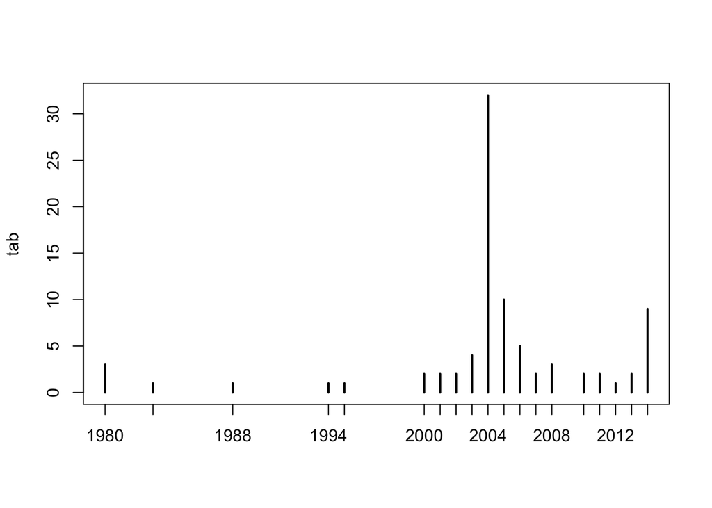

```r
# add predicted topic to dataset
nyt$pred_topic <- topics
nyt$year <- substr(nyt$datetime, 1, 4) # extract year
 # frequency table with articles about inflation, per year
tab <- table(nyt$year[nyt$pred_topic==13])
plot(tab)
```

But we can actually do better than this. LDA is a probabilistic model, which means that for each document, it actually computes a distribution over topics. In other words, each document is considered to be **about a mixture of topics**.

```r
round(lda@gamma[3,], 2)
```

```
##  [1] 0.04 0.04 0.05 0.04 0.03 0.04 0.04 0.06 0.03 0.04 0.03 0.03 0.05 0.04
## [15] 0.04 0.03 0.21 0.03 0.08 0.04
```

So we can actually take the information in the matrix and aggregate it to compute the average probability that an article each year is about a particular topic. Let’s now look again at topic 13.

```r
# Topic 13
paste(terms[,13], collapse=", ")
```

```
## [1] "west, israel, israeli, palestinian, bank, will, barrier, west_bank, palestinians, land, israel's, m, security, attack, building"
```

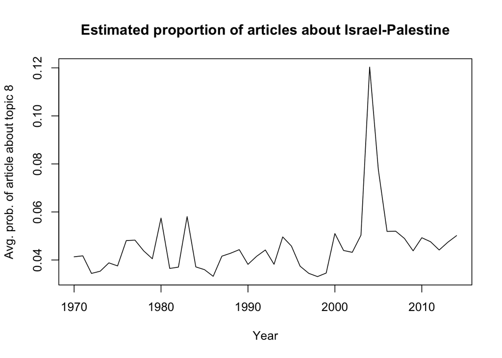

```r
# add probability to df
nyt$prob_topic_13 <- lda@gamma[,13]
# now aggregate at the year level
agg <- aggregate(nyt$prob_topic_13, by=list(year=nyt$year), FUN=mean)
# and plot it
plot(agg$year, agg$x, type="l", xlab="Year", ylab="Avg. prob. of article about topic 8",
     main="Estimated proportion of articles about Israel-Palestine")
```